# Sheltered vs. Unsheltered Codebook

## *Housing Benefits*

*‘13. Are you receiving any of the following benefits? (Select all that apply) - Selected Choice: ’WA Housing and Essential Needs program’ - Imputed with text response.’ This variable is not included for UWRDS-PSD survey observations.*

Sheltered

Receiving Housing Benefits

Sample N

Sample Proportion

RDS II Estimate

RDS II 95% CI

No or Chose Not to Answer

89

95.70%

98.4%

[97.3%, 99.6%]

Yes

4

4.30%

1.6%

[0.4%, 2.7%]

Total

93

Unsheltered

Receiving Housing Benefits

Sample N

Sample Proportion

RDS II Estimate

RDS II 95% CI

No or Chose Not to Answer

565

96.42%

97.1%

[95.9%, 98.4%]

Yes

21

3.58%

2.9%

[1.6%, 4.1%]

Total

586

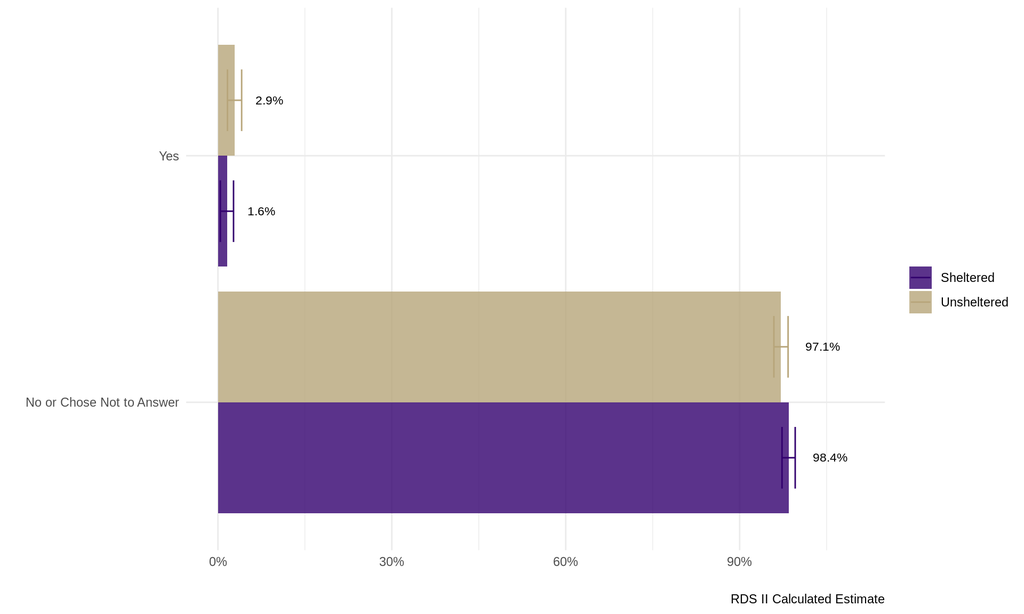

## *SSI Benefits*

*‘13. Are you receiving any of the following benefits? (Select all that apply) - Selected Choice: ’Federal Supplemental Security Income (SSI), Social Security Disability Insurance (SSDI), or other social security benefit’ - Imputed with text response.’ This variable is not included for UWRDS-PSD survey observations.*

Sheltered

Receiving SSI Benefits

Sample N

Sample Proportion

RDS II Estimate

RDS II 95% CI

No or Chose Not to Answer

71

76.3%

81.8%

[67.4%, 96.1%]

Yes

22

23.7%

18.2%

[3.9%, 32.6%]

Total

93

Unsheltered

Receiving SSI Benefits

Sample N

Sample Proportion

RDS II Estimate

RDS II 95% CI

No or Chose Not to Answer

491

83.8%

84.1%

[78.8%, 89.3%]

Yes

95

16.2%

15.9%

[10.6%, 21.2%]

Total

586

*The difference between individual sheltered and unsheltered is not significant, $\chi^2 = 0.34$, (p = 0.536). These results were calculated based on the mean of 1000 bootstrapped tests. This value was calculated with replacement.*

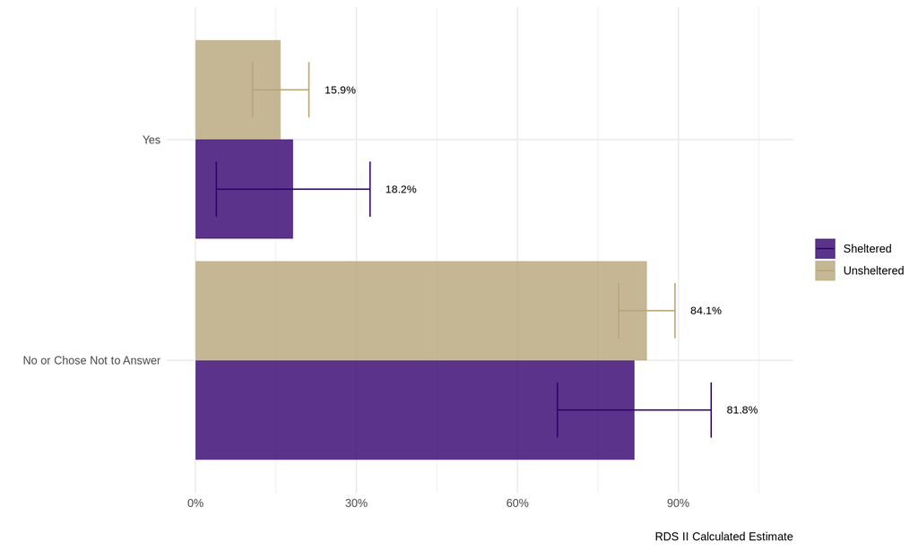

## *Medicaid Benefits*

*‘13. Are you receiving any of the following benefits? (Select all that apply) - Selected Choice: ’Medicaid (in Washington state, this is Apple Health)’ - Imputed with text response.’ This variable is not included for UWRDS-PSD survey observations.*

Sheltered

Receiving Medicaid Benefits

Sample N

Sample Proportion

RDS II Estimate

RDS II 95% CI

No or Chose Not to Answer

44

47.3%

48.2%

[28.6%, 67.9%]

Yes

49

52.7%

51.8%

[32.1%, 71.4%]

Total

93

Unsheltered

Receiving Medicaid Benefits

Sample N

Sample Proportion

RDS II Estimate

RDS II 95% CI

No or Chose Not to Answer

269

45.9%

50.6%

[42.7%, 58.5%]

Yes

317

54.1%

49.4%

[41.5%, 57.3%]

Total

586

*The difference between individual sheltered and unsheltered is not significant, $\chi^2 = 0.19$, (p = 0.696). These results were calculated based on the mean of 1000 bootstrapped tests. This value was calculated with replacement.*

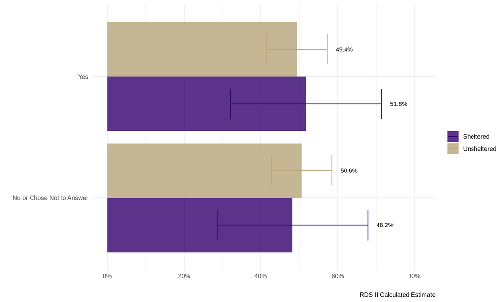

## *Medicare Benefits*

*‘13. Are you receiving any of the following benefits? (Select all that apply) - Selected Choice Medicare’ This variable is not included for UWRDS-PSD survey observations.*

Sheltered

Receiving Medicare Benefits

Sample N

Sample Proportion

RDS II Estimate

RDS II 95% CI

No or Chose Not to Answer

81

87.1%

92%

[86.9%, 97.2%]

Yes

12

12.9%

8%

[2.8%, 13.1%]

Total

93

Unsheltered

Receiving Medicare Benefits

Sample N

Sample Proportion

RDS II Estimate

RDS II 95% CI

No or Chose Not to Answer

519

88.6%

88%

[84.4%, 91.6%]

Yes

67

11.4%

12%

[8.4%, 15.6%]

Total

586

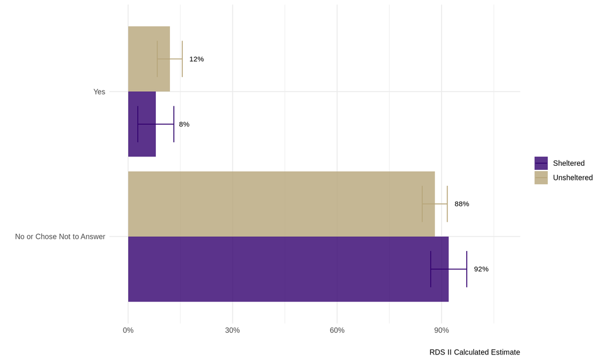

## *Indian Health Service Benefits*

*‘13. Are you receiving any of the following benefits? (Select all that apply) - Selected Choice: ’Indian Health Services’ - Imputed with text response.’ This variable is not included for UWRDS-PSD survey observations.*

Sheltered

Receiving IHS Benefits

Sample N

Sample Proportion

RDS II Estimate

RDS II 95% CI

No or Chose Not to Answer

91

97.85%

98.55%

[97.20%, 99.91%]

Yes

2

2.15%

1.45%

[0.09%, 2.80%]

Total

93

Unsheltered

Receiving IHS Benefits

Sample N

Sample Proportion

RDS II Estimate

RDS II 95% CI

No or Chose Not to Answer

574

97.95%

98.87%

[98.17%, 99.58%]

Yes

12

2.05%

1.13%

[0.42%, 1.83%]

Total

586

*The difference between individual sheltered and unsheltered is not significant, $\chi^2 = 0.07$, (p = 0.835). These results were calculated based on the mean of 1000 bootstrapped tests. This value was calculated with replacement.*

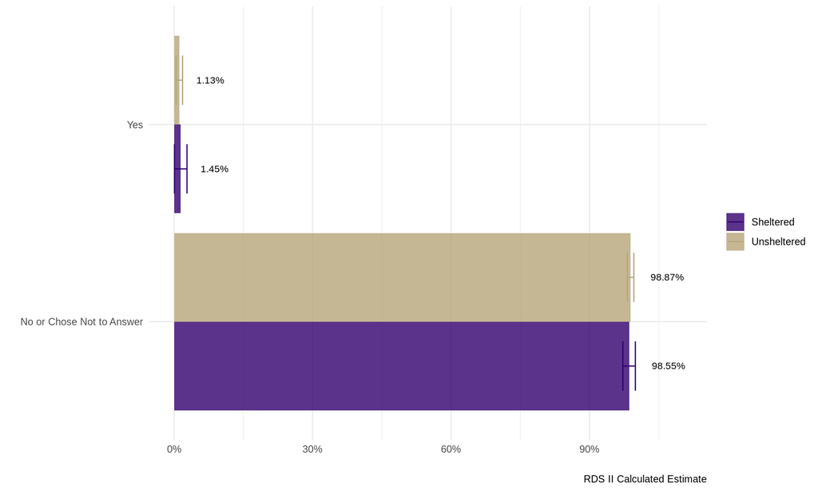

## *Other Benefits*

*‘13. Are you receiving any of the following benefits? - Other - Imputed’ This variable is not included for UWRDS-PSD survey observations.*

Sheltered

Receiving Other Benefits

Sample N

Sample Proportion

RDS II Estimate

RDS II 95% CI

No or Chose Not to Answer

58

62.4%

65.8%

[44.9%, 86.7%]

Yes

35

37.6%

34.2%

[13.3%, 55.1%]

Total

93

Unsheltered

Receiving Other Benefits

Sample N

Sample Proportion

RDS II Estimate

RDS II 95% CI

No or Chose Not to Answer

262

44.7%

45.1%

[37.4%, 52.8%]

Yes

324

55.3%

54.9%

[47.2%, 62.6%]

Total

586

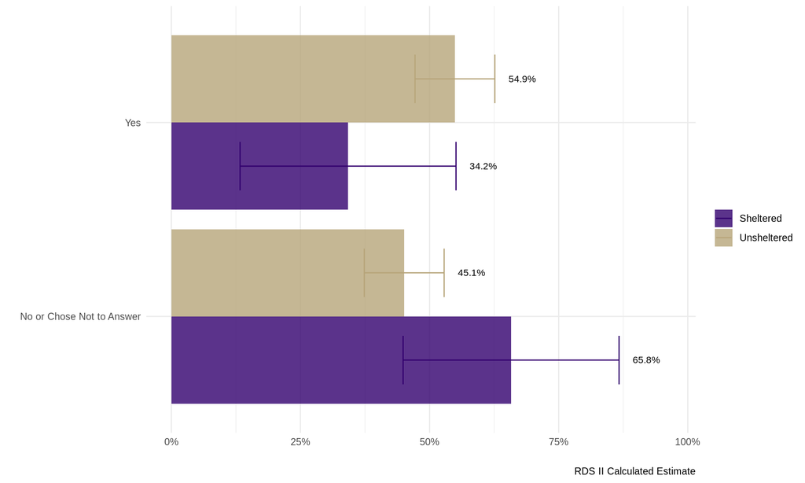